# Homework 5

## Instructions

- Import `income.csv` data first.
- Use the `annual_income_k` and `spending_score` variables throughout.
- Standardize both variables (standard scaling) before clustering.

# Questions

### 1) K-Means clustering

Using the `income.csv` dataset, perform K-Means clustering with `k = 4` on the `annual_income_k` and `spending_score` variables. Before clustering, standardize both variables using standard scaling. Then, using the `ggplot2` package, create a scatter plot with `annual_income_k` on the x-axis and `spending_score` on the y-axis, coloring the points by cluster (four distinct colors).

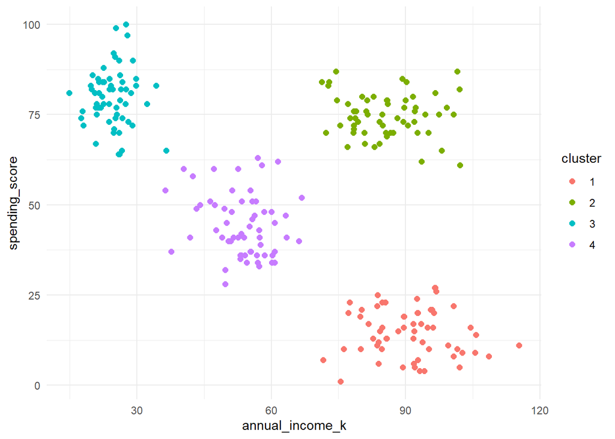

```r
df <- income[c("annual_income_k", "spending_score")]
set.seed(1)
km <- kmeans(scale(df), centers = 4)

library(ggplot2)
df$cluster <- as.factor(km$cluster)
ggplot(df, aes(x = annual_income_k, y = spending_score, color = cluster)) +
  geom_point(size = 2) +
  theme_minimal()
```

### 2) Gaussian mixture model

Using the same two standardized variables, fit a Gaussian mixture model with **4 components** using the `Mclust()` function from the `mclust` package. Report a summary of the fitted model (including the selected covariance structure), and then create a scatter plot with `annual_income_k` on the x-axis and `spending_score` on the y-axis, coloring the points by the GMM cluster assignment (`classification`). Briefly comment on how the resulting clusters compare to the K-Means result from Question 1.

```r
library(mclust)

df_gmm <- income[c("annual_income_k", "spending_score")]
set.seed(1)
gmm <- Mclust(scale(df_gmm), G = 4)
summary(gmm)
```

```
## ----------------------------------------------------
## Gaussian finite mixture model fitted by EM algorithm
## ----------------------------------------------------
##
## Mclust EVI (diagonal, equal volume, varying shape) model with 4 components:
##
##  log-likelihood   n df       BIC       ICL
##       -351.4443 240 16 -790.5789 -791.2698
##
## Clustering table:
##  1  2  3  4
## 60 60 60 60
```

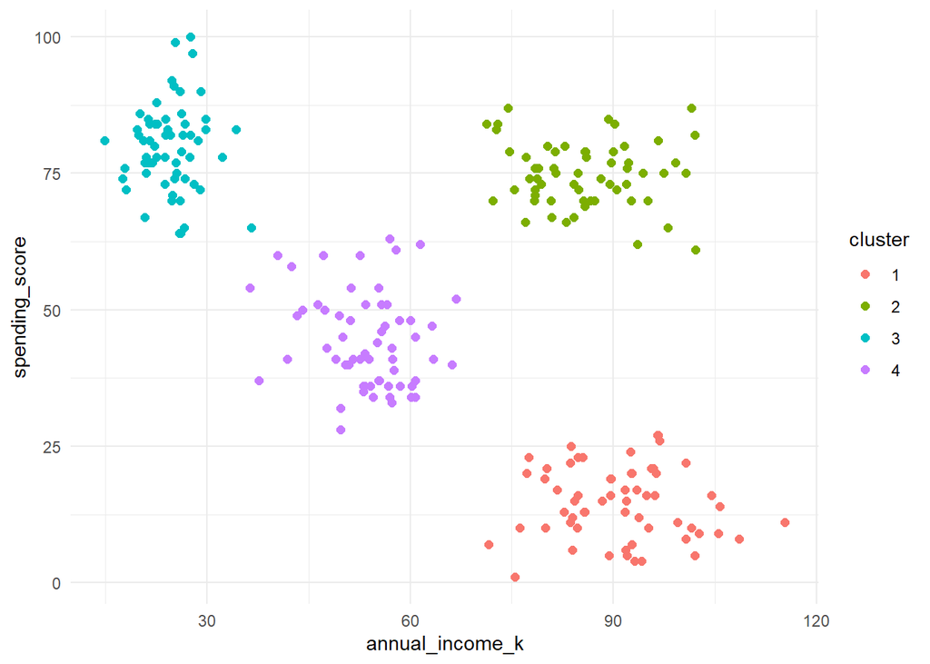

```r
df_gmm$cluster <- as.factor(gmm$classification)
ggplot(df_gmm, aes(x = annual_income_k, y = spending_score, color = cluster)) +
  geom_point(size = 2) +
  theme_minimal()
```

### 3) Hierarchical clustering

Using the same two standardized variables, perform agglomerative hierarchical clustering with **Ward’s method** (`ward.D2`) and Euclidean distance. Plot the resulting dendrogram and use `rect.hclust()` to highlight a cut into 4 clusters. Then cut the tree into 4 clusters with `cutree()`, and create a scatter plot with `annual_income_k` on the x-axis and `spending_score` on the y-axis, coloring the points by cluster.

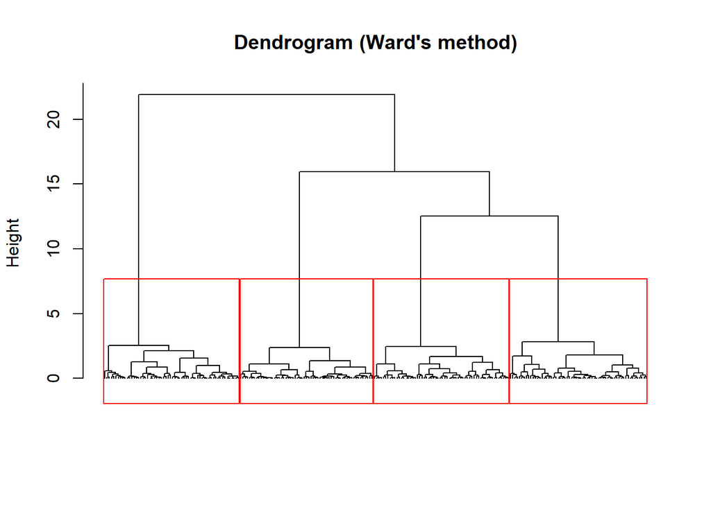

```r
df_hc <- income[c("annual_income_k", "spending_score")]
d  <- dist(scale(df_hc))            # Euclidean distance on standardized data
hc <- hclust(d, method = "ward.D2")

plot(hc, labels = FALSE, hang = -1,
     main = "Dendrogram (Ward's method)", xlab = "", sub = "")
rect.hclust(hc, k = 4, border = "red")
```

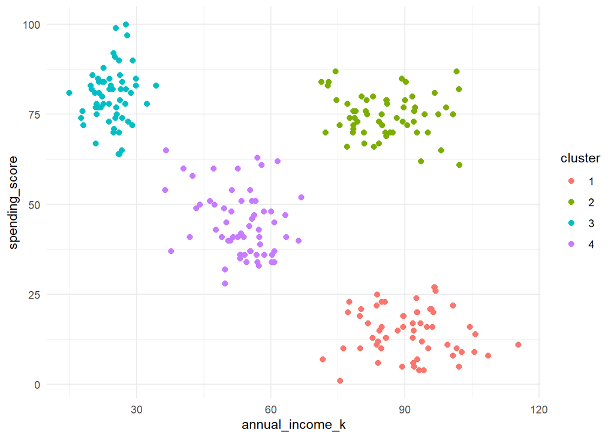

```r
df_hc$cluster <- as.factor(cutree(hc, k = 4))
ggplot(df_hc, aes(x = annual_income_k, y = spending_score, color = cluster)) +
  geom_point(size = 2) +
  theme_minimal()
```